# Problem Set_04

Cheng Ching Ho (31824139)

version March 06, 2018

### Problem set_04 “Fine-scale phylogenetic architecture”

#### Learning objectives:

- Gain experience estimating diversity within a hypothetical microbial community

#### Outline:

In class Day 1:

1. Define and describe species within your group’s “microbial” community.
2. Count and record individuals within your defined species groups.
3. Remix all species together to reform the original community.
4. Each person in your group takes a random sample of the community (*i.e.* devide up the candy).

Assignment:

5. Individually, complete a collection curve for your sample.
6. Calculate alpha-diversity based on your original total community and your individual sample.

In class Day 2:

7. Compare diversity between groups.

#### Part 1: Description and enumeration

Obtain a collection of “microbial” cells from “seawater”. The cells were concentrated from different depth intervals by a marine microbiologist travelling along the Line-P transect in the northeast subarctic Pacific Ocean off the coast of Vancouver Island British Columbia.

Sort out and identify different microbial “species” based on shared properties or traits. Record your data in this Rmarkdown using the example data as a guide.

Once you have defined your binning criteria, separate the cells using the sampling bags provided. These operational taxonomic units (OTUs) will be considered separate “species”. This problem set is based on content available at [What is Biodiversity](http://cnx.org/content/m12179/latest/).

For example, load in the packages you will use.

```r
#To make tables
library(kableExtra)
library(knitr)
#To manipulate and plot data
library(tidyverse)
```

Then load in the data. You should use a similar format to record your community data.

```r
seawater_data = read.csv("candy-data.csv",
                           header = TRUE)
seawater_data_small = read.csv("candy-data_small.csv",
                               header = TRUE)
```

Finally, use these data to create a table.

```r
seawater_data %>%
  kable("html") %>%
  kable_styling(bootstrap_options = "striped", font_size = 10, full_width = F)
```

| X | name | occurances |
| --- | --- | --- |
| 1 | m&m green | 28 |
| 2 | m&m red | 28 |
| 3 | m&m blue | 60 |
| 4 | m&m yellow | 44 |
| 5 | m&m brown | 30 |
| 6 | m&m orange | 63 |
| 7 | skittle brown | 39 |
| 8 | skittle red | 33 |
| 9 | skittle green | 42 |
| 10 | skittle orange | 35 |
| 11 | skittle yellow | 23 |
| 12 | gummi bear red | 15 |
| 13 | gummi bear pink | 16 |
| 14 | gummi bear green | 18 |
| 15 | gummi bear orange | 15 |
| 16 | gummi bear yellow | 19 |
| 17 | gummi bear white | 16 |
| 18 | m&i pink | 39 |
| 19 | m & i green | 36 |
| 20 | m&i yellow | 27 |
| 21 | m&i orange | 32 |
| 22 | m&ired | 40 |
| 23 | worms red | 14 |
| 24 | balls yellow | 4 |
| 25 | balls green | 5 |
| 26 | balls purple | 3 |
| 27 | balls orange | 5 |
| 28 | balls red | 7 |
| 29 | chocolate kiss | 16 |
| 30 | lego pink | 7 |
| 31 | lego yellow | 5 |
| 32 | lego blue | 4 |

```r
seawater_data_small %>%
  kable("html") %>%
  kable_styling(bootstrap_options = "striped", font_size = 10, full_width = F)
```

| X | name | characteristics | occurances |
| --- | --- | --- | --- |
| 1 | green ball | NA | 3 |
| 2 | gummi bear green | NA | 3 |
| 3 | gummi bear red | NA | 2 |
| 4 | gummi bear yellow | NA | 3 |
| 5 | gummi clear | NA | 1 |
| 6 | gummi orange | NA | 3 |
| 7 | m & i green | NA | 4 |
| 8 | m & i orange | NA | 1 |
| 9 | m & i pink | NA | 5 |
| 10 | m & i red | NA | 10 |
| 11 | m & i yellow | NA | 7 |
| 12 | m & m blue | NA | 12 |
| 13 | m & m brown | NA | 4 |
| 14 | m & m green | NA | 4 |
| 15 | m & m orange | NA | 11 |
| 16 | m & m yellow | NA | 5 |
| 17 | m & m red | NA | 2 |
| 18 | pink brick | NA | 1 |
| 19 | purple ball | NA | 2 |
| 20 | red lines | NA | 4 |
| 21 | skittle brown | NA | 2 |
| 22 | skittle green | NA | 10 |
| 23 | skittle orange | NA | 7 |
| 24 | skittle purple | NA | 5 |
| 25 | skittle red | NA | 4 |
| 26 | skittle yellow | NA | 6 |
| NA |  | NA | 121 |

For your community:

- Construct a table listing each species, its distinguishing characteristics, the name you have given it, and the number of occurrences of the species in the collection.
- Ask yourself if your collection of microbial cells from seawater represents the actual diversity of microorganisms inhabiting waters along the Line-P transect. Were the majority of different species sampled or were many missed?

#### Part 2: Collector’s curve

To help answer the questions raised in Part 1, you will conduct a simple but informative analysis that is a standard practice in biodiversity surveys. This analysis involves constructing a collector’s curve that plots the cumulative number of species observed along the y-axis and the cumulative number of individuals classified along the x-axis. This curve is an increasing function with a slope that will decrease as more individuals are classified and as fewer species remain to be identified. If sampling stops while the curve is still rapidly increasing then this indicates that sampling is incomplete and many species remain undetected. Alternatively, if the slope of the curve reaches zero (flattens out), sampling is likely more than adequate.

To construct the curve for your samples, choose a cell within the collection at random. This will be your first data point, such that X = 1 and Y = 1. Next, move consistently in any direction to a new cell and record whether it is different from the first. In this step X = 2, but Y may remain 1 or change to 2 if the individual represents a new species. Repeat this process until you have proceeded through all cells in your collection.

For example, we load in these data.

```r
collection_curve = read.csv("collection_curve.csv",
                            header = FALSE)
```

And then create a plot. We will use a scatterplot (geom_point) to plot the raw data and then add a smoother to see the overall trend of the data.

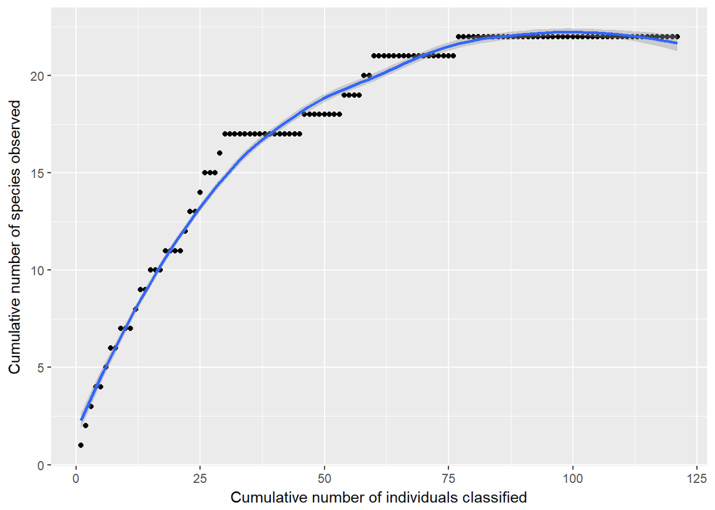

```r
ggplot(collection_curve, aes(x=V1, y=V2)) +
  geom_point() +
  geom_smooth() +
  labs(x="Cumulative number of individuals classified", y="Cumulative number of species observed")
```

For your sample:

- Create a collector’s curve for your sample (not the entire original community).
- Does the curve flatten out? If so, after how many individual cells have been collected?
- What can you conclude from the shape of your collector’s curve as to your depth of sampling?

#### Part 3: Diversity estimates (alpha diversity)

Using the table from Part 1, calculate species diversity using the following indices or metrics.

##### Diversity: Simpson Reciprocal Index

$\frac{1}{D}$ where $D = \sum p_i^2$

$p_i$ = the fractional abundance of the $i^{th}$ species

```r
species1 = 28/(768)
species2 = 28/(768)
species3 = 60/(768)
species4 = 44/(768)
species5 = 30/768
species6 = 63/768
species7 = 39/768
species8 = 33/768
species9 = 42/768
species10 = 35/768
species11 = 23/768
species12 = 15/768
species13 = 16/768
species14 = 18/768
species15 = 15/768
species16 = 19/768
species17 = 16/768
species18 = 39/768
species19 = 36/768
species20 = 27/768
species21 = 32/768
species22 = 40/768
species23 = 14/768
species24 = 4/768
species25 = 5/768
species26 = 3/768
species27 = 5/768
species28 = 7/768
species29 = 16/768
species30 = 7/768
species31 = 5/768
species32 = 4/768
1 / (species1^2 + species2^2 + species3^2 + species4^2 + species5^2 + species6^2 + species7^2 + species8^2 + species9^2 + species10^2 + species11^2 + species12^2 + species13^2 + species14^2 + species15^2 + species16^2 + species17^2 + species18^2 + species19^2 + species20^2 + species21^2 + species22^2 + species23^2 + species24^2 + species25^2 + species26^2 + species27^2 + species28^2 + species29^2 + species30^2 + species31^2 + species32^2)
```

```
## [1] 22.18718
```

```r
Species1 = 3/121
Species2 = 3/121
Species3 = 2/121
Species4 = 3/121
Species5 = 1/121
Species6 = 4/121
Species7 = 1/121
Species8 = 5/121
Species9 = 10/121
Species10 = 7/121
Species11 = 12/121
Species12 = 4/121
Species13 = 4/121
Species14 = 11/121
Species15 = 5/121
Species16 = 2/121
Species17 = 1/121
Species18 = 2/121
Species19 = 4/121
Species20 = 2/121
Species21 = 10/121
Species22 = 7/121
Species23 = 5/121
Species24 = 4/121
Species25 = 6/121
Species26 = 3/121

1/ (Species1^2 + Species2^2 + Species3^2 + Species4^2 + Species5^2 + Species6^2 + Species7^2 + Species8^2 + Species9^2 + Species10^2 + Species11^2 + Species12^2 + Species13^2 + Species14^2 + Species15^2 + Species16^2 + Species17^2 + Species18^2 + Species19^2 + Species20^2 + Species21^2 + Species22^2 + Species23^2 + Species24^2 + Species25^2 + Species26^2 )
```

```
## [1] 18.09765
```

The higher the value is, the greater the diversity. The maximum value is the number of species in the sample, which occurs when all species contain an equal number of individuals. Because the index reflects the number of species present (richness) and the relative proportions of each species with a community (evenness), this metric is a diveristy metric. Consider that a community can have the same number of species (equal richness) but manifest a skewed distribution in the proportion of each species (unequal evenness), which would result in different diveristy values.

##### Richness: Chao1 richness estimator

Another way to calculate diversity is to estimate the number of species that are present in a sample based on the empirical data to give an upper boundary of the richness of a sample. Here, we use the Chao1 richness estimator.

$S_{chao1} = S_{obs} + \frac{a^2}{2b})$

$S_{obs}$ = total number of species observed a = species observed once b = species observed twice or more

```r
26 + 0/(26*2)
```

```
## [1] 26
```

```r
32 + 0/(32*2)
```

```
## [1] 32
```

#### Part 4: Alpha-diversity functions in R

We’ve been doing the above calculations by hand, which is a very good exercise to aid in understanding the math behind these estimates. Not surprisingly, these same calculations can be done with R functions. Since we just have a species table, we will use the `vegan` package. You will need to install this package if you have not done so previously.

```r
library(vegan)
```

First, we must remove the unnecesary data columns and transpose the data so that `vegan` reads it as a species table with species as columns and rows as samples (of which you only have 1).

```r
data_diversity =
  seawater_data %>%
  select(name, occurances) %>%
  spread(name, occurances)

data_diversity
```

```
##   balls green balls orange balls purple balls red balls yellow
## 1           5            5            3         7            4
##   chocolate kiss gummi bear green gummi bear orange gummi bear pink
## 1             16               18                15              16
##   gummi bear red gummi bear white gummi bear yellow lego blue lego pink
## 1             15               16                19         4         7
##   lego yellow m & i green m&i orange m&i pink m&i yellow m&ired m&m blue
## 1           5          36         32       39         27     40       60
##   m&m brown m&m green m&m orange m&m red m&m yellow skittle brown
## 1        30        28         63      28         44            39
##   skittle green skittle orange skittle red skittle yellow worms red
## 1            42             35          33             23        14
```

```r
small_data_diversity =
  seawater_data_small %>%
  select(name, occurances) %>%
  spread(name, occurances)

small_data_diversity
```

```
##    V1 green ball gummi bear green gummi bear red gummi bear yellow
## 1 121          3                3              2                 3
##   gummi clear  gummi orange m & i green m & i orange m & i pink m & i red
## 1            1            3           4            1          5        10
##   m & i yellow m & m blue m & m brown m & m green m & m orange m & m red
## 1            7         12           4           4           11         2
##   m & m yellow  pink brick purple ball red lines skittle brown
## 1             5          1           2         4              2
##   skittle green skittle orange skittle purple skittle red skittle yellow
## 1            10              7              5           4              6
```

Then we can calculate the Simpson Reciprocal Index using the `diversity` function.

```r
diversity(data_diversity, index="invsimpson")
```

```
## [1] 22.18718
```

```r
diversity(small_data_diversity, index = "invsimpson")
```

```
## [1] 3.79055
```

And we can calculate the Chao1 richness estimator (and others by default) with the the `specpool` function for extrapolated species richness. This function rounds to the nearest whole number so the value will be slightly different that what you’ve calculated above.

```r
specpool(data_diversity)
```

```
##     Species chao chao.se jack1 jack1.se jack2 boot boot.se n
## All      32   32       0    32        0    32   32       0 1
```

```r
specpool(small_data_diversity)
```

```
##     Species chao chao.se jack1 jack1.se jack2 boot boot.se n
## All      27   27       0    27        0    27   27       0 1
```

In Project 1, you will also see functions for calculating alpha-diversity in the `phyloseq` package since we will be working with data in that form.

For your sample:

#### Part 5: Concluding activity

If you are stuck on some of these final questions, reading the [Kunin et al. 2010](https://www.ncbi.nlm.nih.gov/pubmed/19725865) and [Lundin et al. 2012](https://www.ncbi.nlm.nih.gov/pubmed/23760801) papers may provide helpful insights.

- How does the measure of diversity depend on the definition of species in your samples? The more specific the definition of speices for our samples, the more diverse our samples appear to be. Whereas if we had a broader definition of what constitutes as a speices (e.g.grouping candy only by colour), then our diversity would lower.
- Can you think of alternative ways to cluster or bin your data that might change the observed number of species? As mentioned, grouping the candy by only their shapes or colour would change the observed number of species.
- How might different sequencing technologies influence observed diversity in a sample? Some sequencing methods might overestimate the diversity and the number of species in a sample.